# Data Science Regression Project: Predicting Home Prices in Banglore

```python
import pandas as pd
import matplotlib.pyplot as plt
import numpy as np
import seaborn as sns
import warnings
warnings.filterwarnings('ignore')
```

# DATA EXPLOR

```python
df1=pd.read_csv("BHP.csv")
df1.head()
```

|  | area_type | availability | location | size | society | total_sqft | bath | balcony | price |
| --- | --- | --- | --- | --- | --- | --- | --- | --- | --- |
| 0 | Super built-up Area | 19-Dec | Electronic City Phase II | 2 BHK | Coomee | 1056 | 2.0 | 1.0 | 39.07 |
| 1 | Plot Area | Ready To Move | Chikka Tirupathi | 4 Bedroom | Theanmp | 2600 | 5.0 | 3.0 | 120.00 |
| 2 | Built-up Area | Ready To Move | Uttarahalli | 3 BHK | NaN | 1440 | 2.0 | 3.0 | 62.00 |
| 3 | Super built-up Area | Ready To Move | Lingadheeranahalli | 3 BHK | Soiewre | 1521 | 3.0 | 1.0 | 95.00 |
| 4 | Super built-up Area | Ready To Move | Kothanur | 2 BHK | NaN | 1200 | 2.0 | 1.0 | 51.00 |

```python
df1.shape
```

```
(13320, 9)
```

```
Super built-up  Area    8790
Built-up  Area          2418
Plot  Area              2025
Carpet  Area              87
Name: area_type, dtype: int64
```

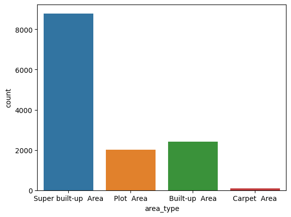

```python
sns.countplot(x=df1.area_type,data=df1)
df1['area_type'].value_counts()
```

Drop features that are not required to build our model

```python
df2=df1.drop(['area_type','availability','society','balcony'],axis=1)
df2.shape
```

```
(13320, 5)
```

```python
df2.head()
```

|  | location | size | total_sqft | bath | price |
| --- | --- | --- | --- | --- | --- |
| 0 | Electronic City Phase II | 2 BHK | 1056 | 2.0 | 39.07 |
| 1 | Chikka Tirupathi | 4 Bedroom | 2600 | 5.0 | 120.00 |
| 2 | Uttarahalli | 3 BHK | 1440 | 2.0 | 62.00 |
| 3 | Lingadheeranahalli | 3 BHK | 1521 | 3.0 | 95.00 |
| 4 | Kothanur | 2 BHK | 1200 | 2.0 | 51.00 |

```python
df2.isnull().sum()
```

```
location       1
size          16
total_sqft     0
bath          73
price          0
dtype: int64
```

# DATA CLENING

```python
df3=df2.dropna()
```

```python
df3.isnull().sum()
```

```
location      0
size          0
total_sqft    0
bath          0
price         0
dtype: int64
```

```python
df3['size'].unique()
```

```
array(['2 BHK', '4 Bedroom', '3 BHK', '4 BHK', '6 Bedroom', '3 Bedroom',
       '1 BHK', '1 RK', '1 Bedroom', '8 Bedroom', '2 Bedroom',
       '7 Bedroom', '5 BHK', '7 BHK', '6 BHK', '5 Bedroom', '11 BHK',
       '9 BHK', '9 Bedroom', '27 BHK', '10 Bedroom', '11 Bedroom',
       '10 BHK', '19 BHK', '16 BHK', '43 Bedroom', '14 BHK', '8 BHK',
       '12 Bedroom', '13 BHK', '18 Bedroom'], dtype=object)
```

Add new feature(integer) for bhk (Bedrooms Hall Kitchen)

```python
df3['bhk']=df3['size'].apply(lambda x:int(x.split(" ")[0]))
```

```python
df3.head(3)
```

|  | location | size | total_sqft | bath | price | bhk |
| --- | --- | --- | --- | --- | --- | --- |
| 0 | Electronic City Phase II | 2 BHK | 1056 | 2.0 | 39.07 | 2 |
| 1 | Chikka Tirupathi | 4 Bedroom | 2600 | 5.0 | 120.00 | 4 |
| 2 | Uttarahalli | 3 BHK | 1440 | 2.0 | 62.00 | 3 |

```python
df3.info()
```

```
<class 'pandas.core.frame.DataFrame'>
Int64Index: 13246 entries, 0 to 13319
Data columns (total 6 columns):
 #   Column      Non-Null Count  Dtype
---  ------      --------------  -----
 0   location    13246 non-null  object
 1   size        13246 non-null  object
 2   total_sqft  13246 non-null  object
 3   bath        13246 non-null  float64
 4   price       13246 non-null  float64
 5   bhk         13246 non-null  int64
dtypes: float64(2), int64(1), object(3)
memory usage: 724.4+ KB
```

```python
df3["total_sqft"].unique()
```

```
array(['1056', '2600', '1440', ..., '1133 - 1384', '774', '4689'],
      dtype=object)
```

```python
def convert_sqft_to_avg(sqft):
    temp=sqft.split('-')
    if len(temp)==2:
        return (float(temp[0])+float(temp[1]))/2
    try:
        return float(sqft)
    except:
        return None

df3["total_sqft"]=df3["total_sqft"].apply(convert_sqft_to_avg)
```

```python
df3.info()
```

```
<class 'pandas.core.frame.DataFrame'>
Int64Index: 13246 entries, 0 to 13319
Data columns (total 6 columns):
 #   Column      Non-Null Count  Dtype
---  ------      --------------  -----
 0   location    13246 non-null  object
 1   size        13246 non-null  object
 2   total_sqft  13200 non-null  float64
 3   bath        13246 non-null  float64
 4   price       13246 non-null  float64
 5   bhk         13246 non-null  int64
dtypes: float64(3), int64(1), object(2)
memory usage: 724.4+ KB
```

```python
df3.isnull().sum()
```

```
location       0
size           0
total_sqft    46
bath           0
price          0
bhk            0
dtype: int64
```

```python
df4=df3.dropna()
df4.isnull().sum()
```

```
location      0
size          0
total_sqft    0
bath          0
price         0
bhk           0
dtype: int64
```

```python
df4.head()
```

|  | location | size | total_sqft | bath | price | bhk |
| --- | --- | --- | --- | --- | --- | --- |
| 0 | Electronic City Phase II | 2 BHK | 1056.0 | 2.0 | 39.07 | 2 |
| 1 | Chikka Tirupathi | 4 Bedroom | 2600.0 | 5.0 | 120.00 | 4 |
| 2 | Uttarahalli | 3 BHK | 1440.0 | 2.0 | 62.00 | 3 |
| 3 | Lingadheeranahalli | 3 BHK | 1521.0 | 3.0 | 95.00 | 3 |
| 4 | Kothanur | 2 BHK | 1200.0 | 2.0 | 51.00 | 2 |

# FEATURE ENGINERING

```python
df4["price_per_sqft"]=df4['price']*100000/df4['total_sqft']
```

```python
df4.head()
```

|  | location | size | total_sqft | bath | price | bhk | price_per_sqft |
| --- | --- | --- | --- | --- | --- | --- | --- |
| 0 | Electronic City Phase II | 2 BHK | 1056.0 | 2.0 | 39.07 | 2 | 3699.810606 |
| 1 | Chikka Tirupathi | 4 Bedroom | 2600.0 | 5.0 | 120.00 | 4 | 4615.384615 |
| 2 | Uttarahalli | 3 BHK | 1440.0 | 2.0 | 62.00 | 3 | 4305.555556 |
| 3 | Lingadheeranahalli | 3 BHK | 1521.0 | 3.0 | 95.00 | 3 | 6245.890861 |
| 4 | Kothanur | 2 BHK | 1200.0 | 2.0 | 51.00 | 2 | 4250.000000 |

```python
len(df4['location'].unique())#dimensionality curse or high dimensinality problem
```

```
1298
```

```python
loc_cou=df4['location'].value_counts()
loc_cou
```

```
Whitefield                   532
Sarjapur  Road               392
Electronic City              302
Kanakpura Road               264
Thanisandra                  232
                            ...
Indiranagar HAL 2nd Stage      1
Maruthi HBCS Layout            1
K R C kothanur                 1
1Channasandra                  1
Abshot Layout                  1
Name: location, Length: 1298, dtype: int64
```

```python
loc_to_change=loc_cou[loc_cou<=20].index.tolist()
df4['location']=df4['location'].apply(lambda x:'other' if x in loc_to_change else x)
```

```python
len(df4['location'].unique())
```

```
144
```

```python
df4.head(10)
```

|  | location | size | total_sqft | bath | price | bhk | price_per_sqft |
| --- | --- | --- | --- | --- | --- | --- | --- |
| 0 | Electronic City Phase II | 2 BHK | 1056.0 | 2.0 | 39.07 | 2 | 3699.810606 |
| 1 | other | 4 Bedroom | 2600.0 | 5.0 | 120.00 | 4 | 4615.384615 |
| 2 | Uttarahalli | 3 BHK | 1440.0 | 2.0 | 62.00 | 3 | 4305.555556 |
| 3 | Lingadheeranahalli | 3 BHK | 1521.0 | 3.0 | 95.00 | 3 | 6245.890861 |
| 4 | Kothanur | 2 BHK | 1200.0 | 2.0 | 51.00 | 2 | 4250.000000 |
| 5 | Whitefield | 2 BHK | 1170.0 | 2.0 | 38.00 | 2 | 3247.863248 |
| 6 | Old Airport Road | 4 BHK | 2732.0 | 4.0 | 204.00 | 4 | 7467.057101 |
| 7 | Rajaji Nagar | 4 BHK | 3300.0 | 4.0 | 600.00 | 4 | 18181.818182 |
| 8 | Marathahalli | 3 BHK | 1310.0 | 3.0 | 63.25 | 3 | 4828.244275 |
| 9 | other | 6 Bedroom | 1020.0 | 6.0 | 370.00 | 6 | 36274.509804 |

# outlier removal

```python
df4[df4.total_sqft/df4.bhk<300].head()
```

|  | location | size | total_sqft | bath | price | bhk | price_per_sqft |
| --- | --- | --- | --- | --- | --- | --- | --- |
| 9 | other | 6 Bedroom | 1020.0 | 6.0 | 370.0 | 6 | 36274.509804 |
| 45 | HSR Layout | 8 Bedroom | 600.0 | 9.0 | 200.0 | 8 | 33333.333333 |
| 58 | other | 6 Bedroom | 1407.0 | 4.0 | 150.0 | 6 | 10660.980810 |
| 68 | other | 8 Bedroom | 1350.0 | 7.0 | 85.0 | 8 | 6296.296296 |
| 70 | other | 3 Bedroom | 500.0 | 3.0 | 100.0 | 3 | 20000.000000 |

```python
df4.shape
```

```
(13200, 7)
```

```python
df6=df4[~(df4.total_sqft/df4.bhk<300)]
df6.shape
```

```
(12456, 7)
```

```
count     12456.000000
mean       6308.502826
std        4168.127339
min         267.829813
25%        4210.526316
50%        5294.117647
75%        6916.666667
max      176470.588235
Name: price_per_sqft, dtype: float64
```

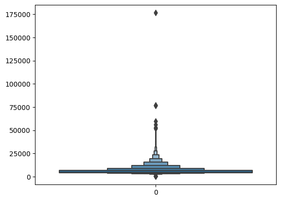

```python
print(df6['price_per_sqft'].describe())
sns.boxenplot(df6.price_per_sqft)
plt.show()
```

```python
def remove_outlier(df):


    df_out = pd.DataFrame()


    for key, subdf in df.groupby('location'):

        m = np.mean(subdf.price_per_sqft)
        st = np.std(subdf.price_per_sqft)


        reduced_df = subdf[(subdf.price_per_sqft > (m - st)) & (subdf.price_per_sqft <= (m + st))]


        df_out = pd.concat([df_out, reduced_df], ignore_index=True)


    return df_out


df7 = remove_outlier(df6)


df7.shape
```

```
(10433, 7)
```

```python
df7['price_per_sqft'].describe()
```

```
count    10433.000000
mean      5602.336189
std       2109.177527
min       1495.513460
25%       4230.769231
50%       5165.562914
75%       6412.478336
max      21875.000000
Name: price_per_sqft, dtype: float64
```

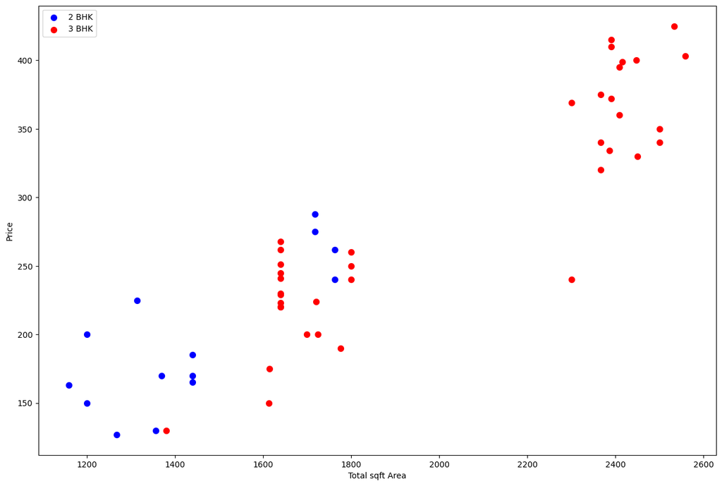

```python
def plot_scatter_chart(df,location):
    bhk2=df[(df.location==location)&(df.bhk==2)]
    bhk3=df[(df.location==location)&(df.bhk==3)]
    plt.figure(figsize=(15,10))
    plt.scatter(bhk2.total_sqft,bhk2.price,color="b",label='2 BHK',s=50)
    plt.scatter(bhk3.total_sqft,bhk3.price,color="r",label='3 BHK',s=50)
    plt.xlabel('Total sqft Area')
    plt.ylabel('Price')
    plt.legend()
    plt.show()
plot_scatter_chart(df7,"Rajaji Nagar")
```

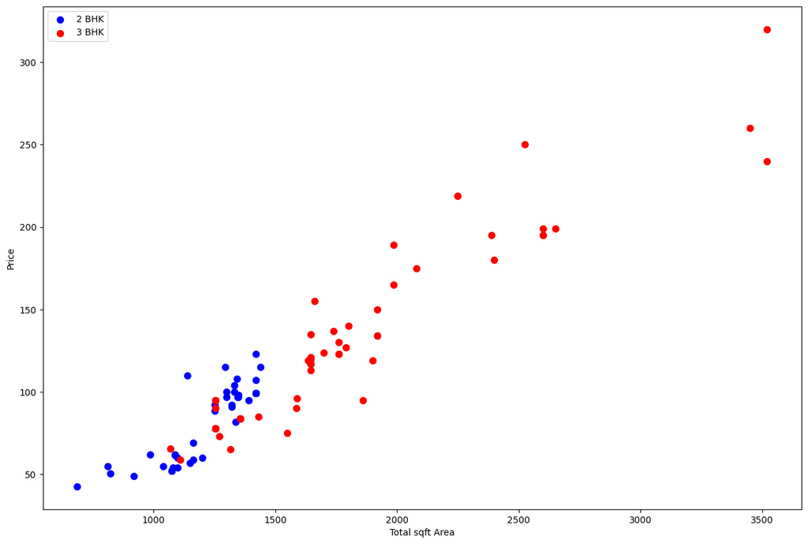

```python
plot_scatter_chart(df7,"Hebbal")
```

```python
def remove_bhk_outliers(df):
    exclude_indices = np.array([])
    for location, location_df in df.groupby('location'):
        bhk_stats = {}
        for bhk, bhk_df in location_df.groupby('bhk'):
            bhk_stats[bhk] = {
                'mean': np.mean(bhk_df.price_per_sqft),
                'std': np.std(bhk_df.price_per_sqft),
                'count': bhk_df.shape[0]
            }
        for bhk, bhk_df in location_df.groupby('bhk'):
            stats = bhk_stats.get(bhk-1)
            if stats and stats['count']>5:
                exclude_indices = np.append(exclude_indices, bhk_df[bhk_df.price_per_sqft<(stats['mean'])].index.values)
    return df.drop(exclude_indices,axis='index')
df8 = remove_bhk_outliers(df7)
# df8 = df7.copy()
df8.shape
```

```
(6988, 7)
```

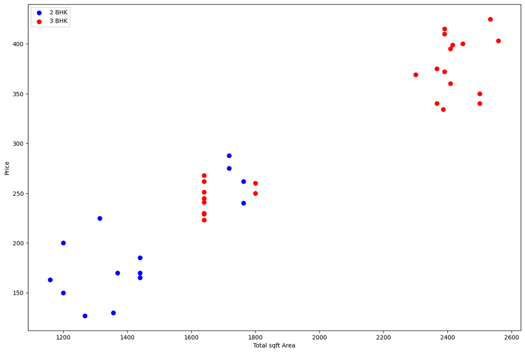

```python
plot_scatter_chart(df8,"Rajaji Nagar")
```

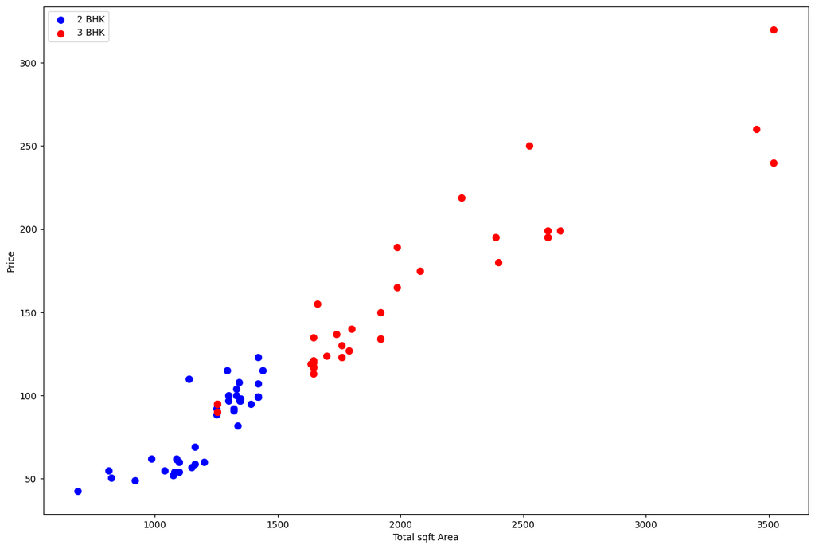

```python
plot_scatter_chart(df8,"Hebbal")
```

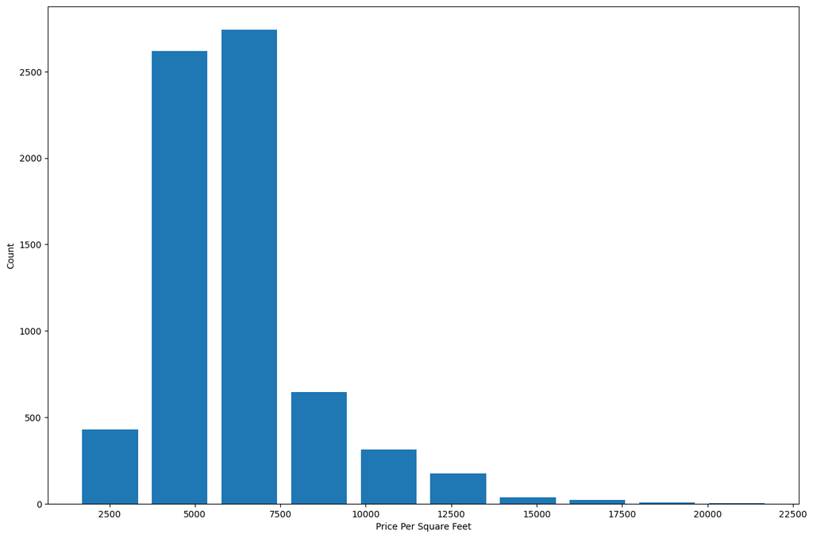

```python
plt.figure(figsize=(15,10))
plt.hist(df8.price_per_sqft,rwidth=0.8)
plt.xlabel("Price Per Square Feet")
plt.ylabel("Count")
```

# Outlier Removal Using Bathrooms Feature

```python
df8.bath.unique()
```

```
array([ 3.,  5.,  4.,  2.,  8.,  1.,  6.,  7.,  9., 12., 16., 13.])
```

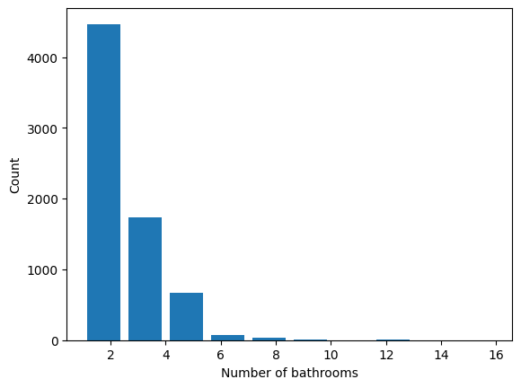

```python
plt.hist(df8.bath,rwidth=0.8)
plt.xlabel("Number of bathrooms")
plt.ylabel("Count")
```

```python
df8[df8.bath>10]
```

|  | location | size | total_sqft | bath | price | bhk | price_per_sqft |
| --- | --- | --- | --- | --- | --- | --- | --- |
| 7818 | other | 10 BHK | 12000.0 | 12.0 | 525.0 | 10 | 4375.000000 |
| 7961 | other | 16 BHK | 10000.0 | 16.0 | 550.0 | 16 | 5500.000000 |
| 9043 | other | 11 BHK | 6000.0 | 12.0 | 150.0 | 11 | 2500.000000 |
| 9216 | other | 10 BHK | 4000.0 | 12.0 | 160.0 | 10 | 4000.000000 |
| 9555 | other | 13 BHK | 5425.0 | 13.0 | 275.0 | 13 | 5069.124424 |

It is unusual to have 2 more bathrooms than number of bedrooms in a home

```python
df8[df8.bath>df8.bhk+2]
```

|  | location | size | total_sqft | bath | price | bhk | price_per_sqft |
| --- | --- | --- | --- | --- | --- | --- | --- |
| 5804 | Thanisandra | 3 BHK | 1806.0 | 6.0 | 116.0 | 3 | 6423.034330 |
| 7695 | other | 6 BHK | 11338.0 | 9.0 | 1000.0 | 6 | 8819.897689 |
| 9917 | other | 4 Bedroom | 7000.0 | 8.0 | 450.0 | 4 | 6428.571429 |

Again the business manager has a conversation with you (i.e. a data scientist) that if you have 4 bedroom home and even if you have bathroom in all 4 rooms plus one guest bathroom, you will have total bath = total bed + 1 max. Anything above that is an outlier or a data error and can be removed

```python
df9 = df8[df8.bath<df8.bhk+2]
df9.shape
```

```
(6909, 7)
```

```python
df9.head(2)
```

|  | location | size | total_sqft | bath | price | bhk | price_per_sqft |
| --- | --- | --- | --- | --- | --- | --- | --- |
| 1 | 1st Phase JP Nagar | 3 BHK | 1875.0 | 3.0 | 167.0 | 3 | 8906.666667 |
| 2 | 1st Phase JP Nagar | 5 Bedroom | 1500.0 | 5.0 | 85.0 | 5 | 5666.666667 |

```python
df10 = df9.drop(['size','price_per_sqft'],axis=1)
df10.head(3)
```

|  | location | total_sqft | bath | price | bhk |
| --- | --- | --- | --- | --- | --- |
| 1 | 1st Phase JP Nagar | 1875.0 | 3.0 | 167.0 | 3 |
| 2 | 1st Phase JP Nagar | 1500.0 | 5.0 | 85.0 | 5 |
| 3 | 1st Phase JP Nagar | 2065.0 | 4.0 | 210.0 | 3 |

# Use One Hot Encoding For Location

```python
dummies = pd.get_dummies(df10.location)
dummies.head(3)
```

|  | 1st Phase JP Nagar | 2nd Stage Nagarbhavi | 5th Phase JP Nagar | 6th Phase JP Nagar | 7th Phase JP Nagar | 8th Phase JP Nagar | 9th Phase JP Nagar | Abbigere | Akshaya Nagar | Ambalipura | ... | Uttarahalli | Varthur | Vidyaranyapura | Vijayanagar | Vittasandra | Whitefield | Yelahanka | Yelahanka New Town | Yeshwanthpur | other |
| --- | --- | --- | --- | --- | --- | --- | --- | --- | --- | --- | --- | --- | --- | --- | --- | --- | --- | --- | --- | --- | --- |
| 1 | 1 | 0 | 0 | 0 | 0 | 0 | 0 | 0 | 0 | 0 | ... | 0 | 0 | 0 | 0 | 0 | 0 | 0 | 0 | 0 | 0 |
| 2 | 1 | 0 | 0 | 0 | 0 | 0 | 0 | 0 | 0 | 0 | ... | 0 | 0 | 0 | 0 | 0 | 0 | 0 | 0 | 0 | 0 |
| 3 | 1 | 0 | 0 | 0 | 0 | 0 | 0 | 0 | 0 | 0 | ... | 0 | 0 | 0 | 0 | 0 | 0 | 0 | 0 | 0 | 0 |

3 rows × 144 columns

```python
df11 = pd.concat([df10,dummies.drop('other',axis='columns')],axis='columns')
df11.head()
```

|  | location | total_sqft | bath | price | bhk | 1st Phase JP Nagar | 2nd Stage Nagarbhavi | 5th Phase JP Nagar | 6th Phase JP Nagar | 7th Phase JP Nagar | ... | Ulsoor | Uttarahalli | Varthur | Vidyaranyapura | Vijayanagar | Vittasandra | Whitefield | Yelahanka | Yelahanka New Town | Yeshwanthpur |
| --- | --- | --- | --- | --- | --- | --- | --- | --- | --- | --- | --- | --- | --- | --- | --- | --- | --- | --- | --- | --- | --- |
| 1 | 1st Phase JP Nagar | 1875.0 | 3.0 | 167.0 | 3 | 1 | 0 | 0 | 0 | 0 | ... | 0 | 0 | 0 | 0 | 0 | 0 | 0 | 0 | 0 | 0 |
| 2 | 1st Phase JP Nagar | 1500.0 | 5.0 | 85.0 | 5 | 1 | 0 | 0 | 0 | 0 | ... | 0 | 0 | 0 | 0 | 0 | 0 | 0 | 0 | 0 | 0 |
| 3 | 1st Phase JP Nagar | 2065.0 | 4.0 | 210.0 | 3 | 1 | 0 | 0 | 0 | 0 | ... | 0 | 0 | 0 | 0 | 0 | 0 | 0 | 0 | 0 | 0 |
| 5 | 1st Phase JP Nagar | 2059.0 | 3.0 | 225.0 | 3 | 1 | 0 | 0 | 0 | 0 | ... | 0 | 0 | 0 | 0 | 0 | 0 | 0 | 0 | 0 | 0 |
| 6 | 1st Phase JP Nagar | 1394.0 | 2.0 | 100.0 | 2 | 1 | 0 | 0 | 0 | 0 | ... | 0 | 0 | 0 | 0 | 0 | 0 | 0 | 0 | 0 | 0 |

5 rows × 148 columns

```python
df12 = df11.drop('location',axis='columns')
df12.head(2)
```

|  | total_sqft | bath | price | bhk | 1st Phase JP Nagar | 2nd Stage Nagarbhavi | 5th Phase JP Nagar | 6th Phase JP Nagar | 7th Phase JP Nagar | 8th Phase JP Nagar | ... | Ulsoor | Uttarahalli | Varthur | Vidyaranyapura | Vijayanagar | Vittasandra | Whitefield | Yelahanka | Yelahanka New Town | Yeshwanthpur |
| --- | --- | --- | --- | --- | --- | --- | --- | --- | --- | --- | --- | --- | --- | --- | --- | --- | --- | --- | --- | --- | --- |
| 1 | 1875.0 | 3.0 | 167.0 | 3 | 1 | 0 | 0 | 0 | 0 | 0 | ... | 0 | 0 | 0 | 0 | 0 | 0 | 0 | 0 | 0 | 0 |
| 2 | 1500.0 | 5.0 | 85.0 | 5 | 1 | 0 | 0 | 0 | 0 | 0 | ... | 0 | 0 | 0 | 0 | 0 | 0 | 0 | 0 | 0 | 0 |

2 rows × 147 columns

# Build a Model Now...

```python
df12.shape
```

[output not shown]

```python
X = df12.drop(['price'],axis='columns')
X.head(3)
```

|  | total_sqft | bath | bhk | 1st Phase JP Nagar | 2nd Stage Nagarbhavi | 5th Phase JP Nagar | 6th Phase JP Nagar | 7th Phase JP Nagar | 8th Phase JP Nagar | 9th Phase JP Nagar | ... | Ulsoor | Uttarahalli | Varthur | Vidyaranyapura | Vijayanagar | Vittasandra | Whitefield | Yelahanka | Yelahanka New Town | Yeshwanthpur |
| --- | --- | --- | --- | --- | --- | --- | --- | --- | --- | --- | --- | --- | --- | --- | --- | --- | --- | --- | --- | --- | --- |
| 1 | 1875.0 | 3.0 | 3 | 1 | 0 | 0 | 0 | 0 | 0 | 0 | ... | 0 | 0 | 0 | 0 | 0 | 0 | 0 | 0 | 0 | 0 |
| 2 | 1500.0 | 5.0 | 5 | 1 | 0 | 0 | 0 | 0 | 0 | 0 | ... | 0 | 0 | 0 | 0 | 0 | 0 | 0 | 0 | 0 | 0 |
| 3 | 2065.0 | 4.0 | 3 | 1 | 0 | 0 | 0 | 0 | 0 | 0 | ... | 0 | 0 | 0 | 0 | 0 | 0 | 0 | 0 | 0 | 0 |

3 rows × 146 columns

```python
y = df12.price
y.head(3)
```

```
1    167.0
2     85.0
3    210.0
Name: price, dtype: float64
```

```python
from sklearn.model_selection import train_test_split
X_train, X_test, y_train, y_test = train_test_split(X,y,test_size=0.2,random_state=10)
```

```python
from sklearn.linear_model import LinearRegression
lr_clf = LinearRegression()
lr_clf.fit(X_train,y_train)
lr_clf.score(X_test,y_test)
```

```
0.8863497424105062
```

# Use K Fold cross validation to measure accuracy of our LinearRegression model

```python
from sklearn.model_selection import ShuffleSplit
from sklearn.model_selection import cross_val_score

cv = ShuffleSplit(n_splits=5, test_size=0.2, random_state=0)

cross_val_score(LinearRegression(), X, y, cv=cv)
```

```
array([0.85909809, 0.78671328, 0.84664769, 0.79860268, 0.81676725])
```

# Find best model using GridSearchCV

```python
from sklearn.model_selection import GridSearchCV, ShuffleSplit
from sklearn.linear_model import LinearRegression, Lasso
from sklearn.tree import DecisionTreeRegressor
import pandas as pd

def find_best_model_using_gridsearchcv(X, y):
    algos = {
        'linear_regression': {
            'model': LinearRegression(),
            'params': {}
        },
        'lasso': {
            'model': Lasso(),
            'params': {
                'alpha': [1, 2],
                'selection': ['random', 'cyclic']
            }
        },
        'decision_tree': {
            'model': DecisionTreeRegressor(),
            'params': {
                'criterion': ['mse', 'friedman_mse'],
                'splitter': ['best', 'random']
            }
        }
    }
    scores = []
    cv = ShuffleSplit(n_splits=5, test_size=0.2, random_state=0)
    for algo_name, config in algos.items():
        gs = GridSearchCV(config['model'], config['params'], cv=cv, return_train_score=False)
        gs.fit(X, y)
        scores.append({
            'model': algo_name,
            'best_score': gs.best_score_,
            'best_params': gs.best_params_
        })

    return pd.DataFrame(scores, columns=['model', 'best_score', 'best_params'])

# Replace X and y with your actual data
# X = ...
# y = ...

find_best_model_using_gridsearchcv(X, y)
```

|  | model | best_score | best_params |
| --- | --- | --- | --- |
| 0 | linear_regression | 0.821566 | {} |
| 1 | lasso | 0.733743 | {'alpha': 1, 'selection': 'random'} |
| 2 | decision_tree | 0.655865 | {'criterion': 'friedman_mse', 'splitter': 'best'} |

Based on above results we can say that LinearRegression gives the best score. Hence we will use that.

# Test the model for few properties

```python
def predict_price(location,sqft,bath,bhk):
    loc_index = np.where(X.columns==location)[0][0]

    x = np.zeros(len(X.columns))
    x[0] = sqft
    x[1] = bath
    x[2] = bhk
    if loc_index >= 0:
        x[loc_index] = 1

    return lr_clf.predict([x])[0]
```

```python
print(predict_price('1st Phase JP Nagar',1000, 2, 2))
print(predict_price('1st Phase JP Nagar',1000, 3, 3))
print(predict_price('Indira Nagar',1000, 2, 2))
print(predict_price('Indira Nagar',1000, 3, 3))
```

```
86.0922323917882
85.85866784461692
169.01605371774968
168.7824891705784
```

# Export the tested model to a pickle file

```python
import pickle
with open('banglore_home_prices_model.pickle','wb') as f:
    pickle.dump(lr_clf,f)
```

# Export location and column information to a file that will be useful later on in our prediction application

```python
import json
columns = {
    'data_columns' : [col.lower() for col in X.columns]
}
with open("columns.json","w") as f:
    f.write(json.dumps(columns))
```